# Movie Exploration

### Related Work:

Since our data is about movie and our purpose is to explore such data and figure out some analysis related to such dataset, Shiny app becomes an appropriate tool for us to make such dataset visualized. Moreover, in the Shiny app gallery, we found one perfect instance for our project.[Movie Explorer](https://shiny.rstudio.com/gallery/movie-explorer.html). In such example, the data is from a subset of data from the [OMDb](http://www.omdbapi.com/) that is saved in an SQLite database and came from IMDb and Rotten Tomatoes.

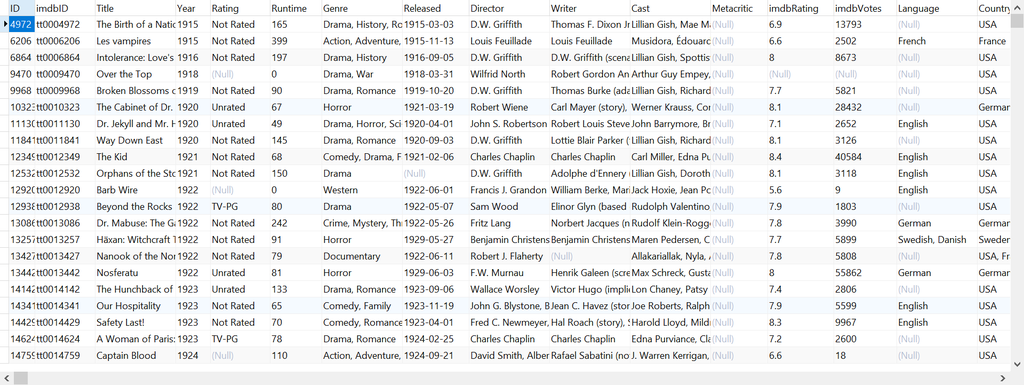

The major function for this Shiny app is to display a plot with information that selected by the users; for instance, the users can choose the released year, number of Oscar wins, or genre of the movies and the app will make a relative plot based on those selections, which we also have discussed in the class. Moreover, the users can select the x-axis and y-axis that corresponding to different variables in the database. Besides, the users can search for specific director or cast members and the app will filter such movies with information on the plot.

Therefore, we were inspired by such work and decided to achieve similar functions that included in this app by our own dataset and try to understand the method to produce a successful movie.

### Exploratory Analysis:

By exploring our own data set which came from the IMDb website with the purpose to build a Shiny app with similar function as the example from the gallery, we divided the tasks into three parts that related to our courses:

#### 1.

Based on the released year and box office from the movie, the user can utilize two sliders with four inputs value to filter the specific movies. This part is relatively easy for us to achieve since we already did in the homework; therefore, we just revised the code we put in the homework and tested whether it works or not. Instead of previous slider input with one value, we chose to make two values for each slider input which provide more flexibility for the users, by setting the maximum and minimum value of year and box office.

#### 2.

Based on the country, language, and genre of the movie, the user can decide each feature from a select input, containing all kinds of features of movies. Furthermore, they can choose the x-axis and y-axis with different information. For this process, thanks to our data scraping method, we separated the column of each feature into a binary input value for each movie so that we can simply filter the information from the data set based on the selection of the user. Therefore, by listing the key words for each genre, country, and language of the movies, the app can filter the data set by input a character from the “selectInput” list and such character input will be renamed to fit the column name and be transferred into a data set that can work in the “filter()” function by applying “.data[]”.Moreover, to achieve the selection of the x-axis and y-axis, we tried the code from the instance from the Shiny gallery; however, it did not work, and we were not familiar with the package named “javascript” and “ggvis” inside that example. Thus, we had to utilize the “if()” function to achieve such function. Although it worked in the Shiny app, it contained tons of code which might be replaced by other methods.

#### 3.

By clicking or brush on specific points, the users can get a table of information about those particular movies. In the beginning, we wanted to make the function that once the users move the cursor key onto the points on the plot, the plot would show messages of that specific movie to the users, which is similar with the function in the example app. However, we found that such function was achieved by utilizing Java in the Shiny app so that we gave up such idea and chose to utilize the previous click function that we did in the homework. Although the click and brush functions worked fine on the app, since some movies had long cast list, the table displaced on the app had an excessively long list of the cast which we did not know how to adjust. Moreover, the size of the tables is fixed, although we edited the length of the column, it still displaced the information table in several lines instead of one single line.

Last but not least, we abandoned the search function for the cast; we tried many methods to achieve that and we found one useful method with everything working in the normal R code without user input value. However, after we change such code into the Shiny app, for no reasons, it did not work anymore. Thus, after tons of attempts on this function which still not working, we decided to cut such function and make more efforts in other parts.